# Graphs for TxGraffiti

K Shoemaker

2/11/2021

Load in the data, note that `NA` is 1000000

```r
# load in data
graph_data <- read.csv("test_graph_data_with_index2.csv", na.strings = "1000000")
glimpse(graph_data)
```

```
## Rows: 1,695
## Columns: 46
## $ networkx_graph                     <chr> "3,6_cubic_cage.txt", "Diamond_Neck…
## $ domination_number                  <int> 4, 3, 2, 1, 2, 2, 2, 1, 2, 2, 2, 1,…
## $ total_domination_number            <int> 6, 5, 3, 2, 2, 2, 2, 2, 2, 2, 2, 2,…
## $ connected_domination_number        <int> 6, 7, 3, 1, 2, 2, 2, 1, 2, 2, 2, 1,…
## $ independence_number                <int> 7, 4, 3, 4, 3, 3, 3, 3, 2, 3, 2, 3,…
## $ power_domination_number            <int> 2, 3, 1, 1, 1, 1, 1, 1, 1, 1, 1, 1,…
## $ zero_forcing_number                <int> 6, 5, 1, 3, 2, 2, 2, 2, 2, 3, 2, 2,…
## $ diameter                           <int> 3, 4, 4, 2, 3, 3, 3, 2, 3, 2, 2, 2,…
## $ radius                             <int> 3, 4, 2, 1, 2, 2, 2, 1, 2, 2, 2, 1,…
## $ order                              <int> 14, 12, 5, 5, 5, 5, 5, 5, 5, 5, 5, …
## $ independent_domination_number      <int> 4, 3, 2, 1, 2, 2, 2, 1, 2, 2, 2, 1,…
## $ chromatic_number                   <int> 2, 3, 2, 2, 2, 2, 3, 3, 3, 2, 3, 3,…
## $ matching_number                    <int> 7, 6, 2, 1, 2, 2, 2, 2, 2, 2, 2, 2,…
```

[output cut: 33 more lines]

Set up some variables about the variables

```r
# names and count of numeric variables
numeric_vars <- colnames(graph_data)[c(2:34,46)]
n_num <- length(numeric_vars)

# names and count of boolean variables
binary_vars <- colnames(graph_data)[35:45]
n_bin <- length(binary_vars)
```

# dot plots, factorized

```r
n_sample <- sample(numeric_vars, 2, replace = F)
b_sample <- sample(binary_vars, 2, replace = F)

subset_data <- graph_data %>% select(n_sample, b_sample)
```

[output not shown]

[output not shown]

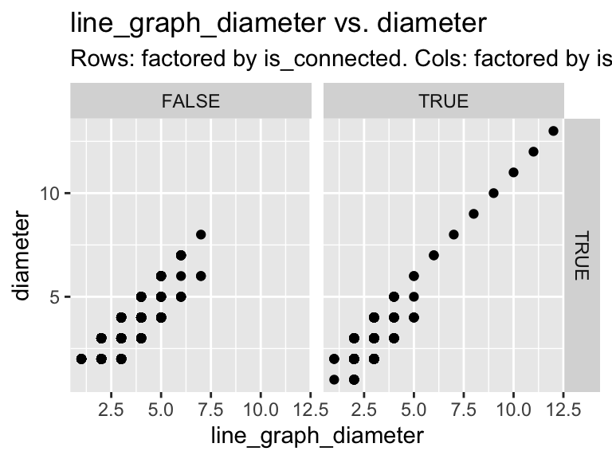

```r
this_title <- paste(n_sample[1], "vs.", n_sample[2])
this_subtitle <- paste0("Rows: factored by ", b_sample[1], ". Cols: factored by ", b_sample[2])
ggplot(subset_data, aes(x = subset_data[,1], y = subset_data[,2])) + geom_point() + facet_grid(subset_data[,3] ~ subset_data[,4])  + labs(x = n_sample[1], y = n_sample[2], title = this_title, subtitle = this_subtitle)
```

# New data

```r
graph_data_2 <- read.csv("test_graph_data.csv", na.strings = "1000000")
```

```r
# setup
# names and count of numeric variables
numeric_vars <- colnames(graph_data_2)[2:52]
n_num <- length(numeric_vars)

# names and count of boolean variables
binary_vars <- colnames(graph_data_2)[53:71]
n_bin <- length(binary_vars)
```

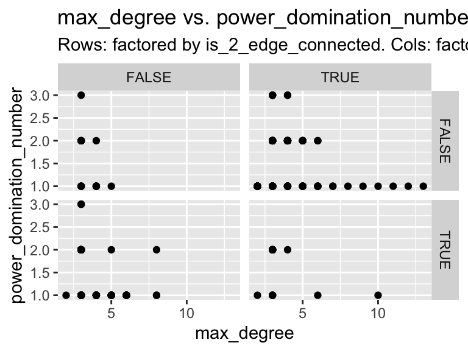

```r
n_sample <- sample(numeric_vars, 2, replace = F)
b_sample <- sample(binary_vars, 2, replace = F)

subset_data <- graph_data_2 %>% select(n_sample, b_sample)
this_title <- paste(n_sample[1], "vs.", n_sample[2])
this_subtitle <- paste0("Rows: factored by ", b_sample[1], ". Cols: factored by ", b_sample[2])
ggplot(subset_data, aes(x = subset_data[,1], y = subset_data[,2])) + geom_point() + facet_grid(subset_data[,3] ~ subset_data[,4])  + labs(x = n_sample[1], y = n_sample[2], title = this_title, subtitle = this_subtitle)
```

# Old Things

Several viz options, in no particular order. Load in and look at data first, note that the `NA` character is `1000000`.

# Density plots (emperical distributions)

First option would be just a density plot of these ratios you’ve referenced. My first thought was to do histograms, but since it’s all integer values, that looks choppy and bad.

Example 1a: order over power domination number, histogram

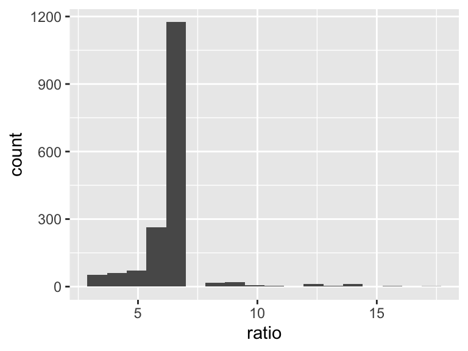

```r
graph_data %>%
  mutate(ratio = order / power_domination_number) %>%
  ggplot(aes(x = ratio)) + geom_histogram(bins = 18)
```

Example 1b: order over power domination number, density plot

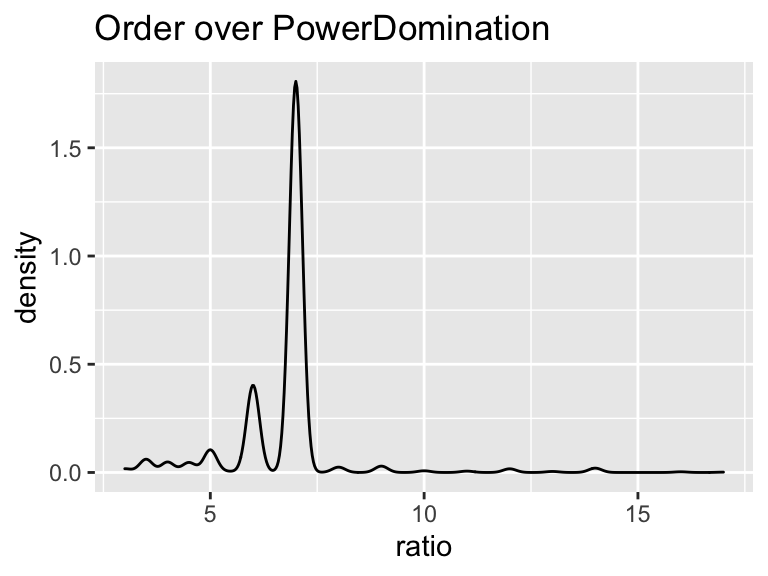

```r
graph_data %>%
  mutate(ratio = order / power_domination_number) %>%
  ggplot(aes(x = ratio)) +
  geom_density() +
  labs(title = "Order over PowerDomination")
```

# Density plots, by group

Same plot as previous, but divided by one of the binary classifications.

Example 2a: order over power domination number, density plot, divided by whether it’s cubic or not, overlaid

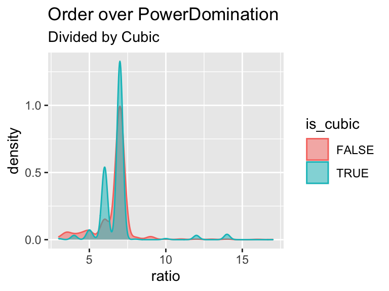

```r
graph_data %>%
  mutate(ratio = order / power_domination_number) %>%
  ggplot(aes(x = ratio, color = is_cubic, fill = is_cubic)) +
  geom_density(alpha = 0.5) +
  labs(title = "Order over PowerDomination", subtitle =  "Divided by Cubic")
```

Example 2b: order over power domination number, density plot, divided by whether it’s cubic or not, split up

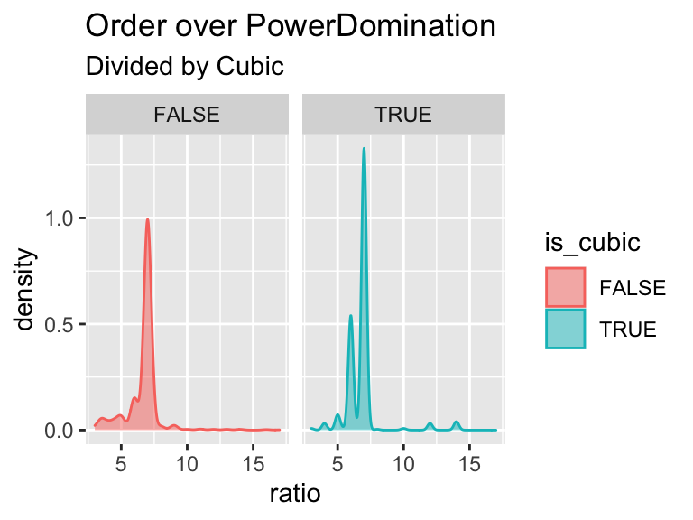

```r
graph_data %>%
  mutate(ratio = order / power_domination_number) %>%
  ggplot(aes(x = ratio, color = is_cubic, fill = is_cubic)) +
  geom_density(alpha = 0.5) +
  facet_wrap(. ~is_cubic) +
  labs(title = "Order over PowerDomination", subtitle =  "Divided by Cubic")
```

# Scatter plots

These are tricky, since they all just stack on top of each other.

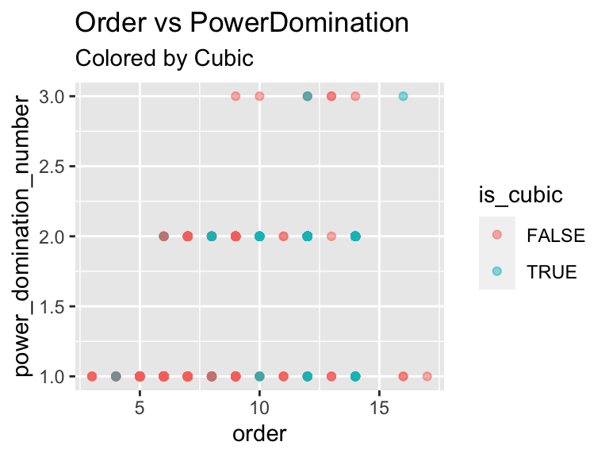

```r
graph_data %>%
  ggplot(aes(x = order, y = power_domination_number, color = is_cubic)) +
  geom_point(alpha = 0.5) +
  labs(title = "Order vs PowerDomination", subtitle =  "Colored by Cubic")
```

You can add in a little “jitter” to make them space out a little to see what’s happening, but I still don’t love it.

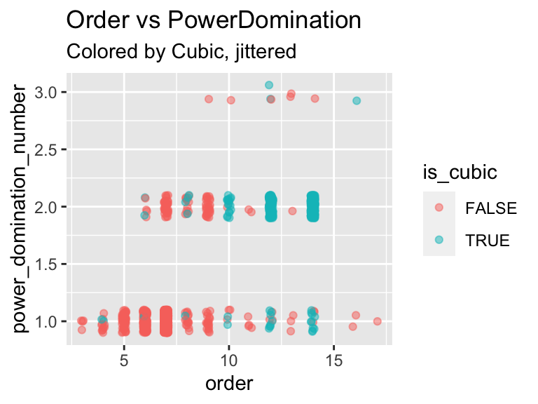

```r
graph_data %>%
  ggplot(aes(x = order, y = power_domination_number, color = is_cubic)) +
  geom_jitter(alpha = 0.5, width = 0.1, height = 0.1) +
  labs(title = "Order vs PowerDomination", subtitle =  "Colored by Cubic, jittered")
```

If we do a heatmap, we’d also need to facet…

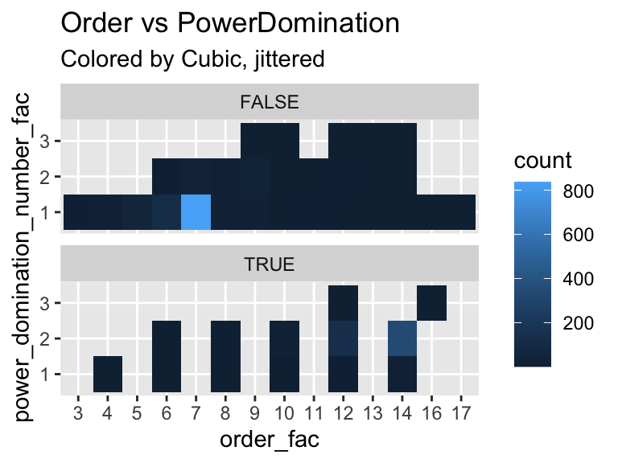

```r
# note: made these an ordered factor, might want to do this for everything for nicer graphing.
graph_data %>%
  mutate(order_fac = factor(order, ordered = T), power_domination_number_fac = factor(power_domination_number, ordered = T)) %>%
  ggplot(aes(x = order_fac, y = power_domination_number_fac)) +
  geom_bin2d(bins = c(15,3)) + facet_wrap(. ~ is_cubic, nrow = 2) +
  labs(title = "Order vs PowerDomination", subtitle =  "Colored by Cubic, jittered")
```

> did this on accident, thought it looked cool. lol.

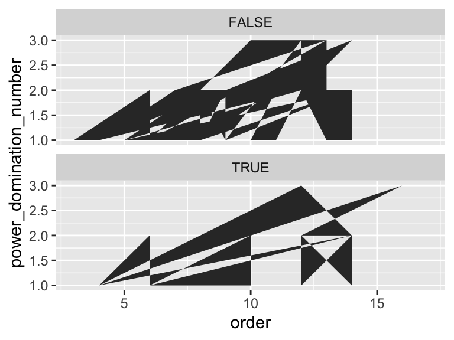

```r
graph_data %>%
  ggplot(aes(x = order, y = power_domination_number)) +
  geom_polygon() + facet_wrap(. ~ is_cubic, nrow = 2)
```

```r
  labs(title = "Order vs PowerDomination", subtitle =  "Colored by Cubic, jittered")
```

```
## $title
## [1] "Order vs PowerDomination"
##
## $subtitle
## [1] "Colored by Cubic, jittered"
##
## attr(,"class")
## [1] "labels"
```

# Viz of graph properties

> the independence number is <= number of vertices / 2, what are the properties of those graphs